# TNUM ASSIGNMENT

Jiaqi Sun, Yaquan Yang, Hao He, Kaiwei Xiao

2022-11-10

```r
a <- tnum.getAllSubjects()
b <- tnum.getAllProperties()
c <- tnum.getAllTags()
d <- tnum.getSpace()
```

# Assignment Part 1: Text Analysis with Truenumbers

## Character Exploration:

### Where Weena is mentioned

53 results back, suggesting that Weena is one of the most important character in the Time Machine. We are going to keep searching every character associated with her.

```r
time_weena <- tnum.query("stringval:weena")%>%
  select(subject, value) %>%
  separate(subject, sep=":",
    into=c("book","chap","chap_no", "sent","sent_no")) %>%
  select(chap_no, sent_no, value)

   time_weena$chap_no <- as.numeric(time_weena$chap_no)
   time_weena$sent_no <- as.numeric(time_weena$sent_no)

time_weena %<>% arrange(chap_no, sent_no)

w <- tnum.query("stringval:weena*")

#use graph to see the chapter# and sentence# Weena appears
tnum.graphPathList(w$subject)
```

[interactive chart not shown]

We can clearly see from the chapters and sentences where Weena is mentioned, that the character Weena and “Me”-the time traveller, is closely tighted. Weena was rescued by the time traveller and showed her love and loyalty to him. Yet, Weena has something to do with the Underworld (which is believed to be Eloi people, we searched them in the book too) and she was not exactly a human. The Time Traveller left and came back to Weena, only to see that she is disappeared with a small blue disc. After, they proceeded over the hill crest towards Wimbledon, Weena was both tired and scared, all she wanted is to go back to the house of grey stone. Morlocks ( we are going to searched them in the book too) has been disturbing the time traveller for a while, he want to fight against them through solving the puzzle and he thought something horrible was coming upon him. They went to the forest and found an a machine, odd noises showing up and Weena was worried and whimpered. But the time traveller could not kill the brutes in the gallery beacuse slake the thirst for murder his Time Machine might suffer. As they continued their journey in the forest in the darkness, Weena was afraid and became motionless, two white forms tried to approaching Weena. Then Weena left, or I have to say she might dead, the time traveller’s heart broken. Unable to find her, The Time Traveler returned to his own time.

Weena is an Eloi woman whom the Time Traveller saves from drowning. Though he does not expect gratitude or recognition in return for his bravery, Weena surprises and charms the Time Traveller by following him everywhere from then on and adorning him constantly with flowers as a sign of gratitude and affection. The Time Traveller learns important things from Weena (including that fear is, after all, a pervasive feeling among the Eloi), and it is through her companionship that he begins to feel that this strange future is his home. Nonetheless, he is conflicted about how human she really is—she’s not particularly intelligent, but, as the Time Traveller says, “She always seemed to me, I fancy, more human than she was, perhaps because her affection was so human.” Thus Weena is a being defined by kindness, and her death in a forest fire that the Time Traveller inadvertently started is a tragedy.

### Where Morlock is mentioned

```r
time_morlock <- tnum.query("stringval:morlock") %>%
                select(subject, value) %>%
                separate(subject, sep=":",
    into=c("book","chap","chap_no", "sent","sent_no")) %>%
     select(chap_no, sent_no, value)
```

```
## Returned 52 results
```

```r
    time_morlock$chap_no <- as.numeric(time_morlock$chap_no)
    time_morlock$sent_no <- as.numeric(time_morlock$sent_no)

    time_morlock %<>% arrange(chap_no, sent_no)
```

Morlock, as a humanoid creature who live underground, whose eyes are sensitive to light, using a series of wells to pump air into their tunnels, as well as other methods. They were more technologically advanced than the Eloys, retaining more remnants of human technology. They had taken the time machine from the time traveller. They were carnivorous but their food had run out long time ago, they preserved and preyed upon Eloi (believed to be Morlocks’ cousins, which we will search in the book later). They are dexterous climbers. They used to live underground and serve upperworld but cannot stand it anymore. The time traveller thought Morlocks are disgusting: inhuman and malign. The Morlocks are afraid of fire. The time traveller got into a fight with the Morlocks in the forest.

The Morlocks, who, though disgusting and inhuman, “retained…more initiative” and even “some little thought outside habit” (10.4). That’s faint praise, but it’s enough to show us that the Eloi and the Morlocks serve as mirror images of each other.

While the Morlock’s are presented as evil in the book they can be viewed with more sympathy when looking at how they developed, they grew used to their working conditions and adapted their relationship with the Eloi where they benefit from keeping them alive in order to use them for food. If the working class were treated better and the upper class did more work thing may have turned out differently.

### Where Weena and Morlock are mentioned at the same time

```r
time_wee_mor <- tnum.query("stringval:weena and stringval:morlock") %>%
               select(subject, value) %>%
               separate(subject, sep=":",
      into=c("book","chap","chap_no", "sent","sent_no")) %>%
               select(chap_no, sent_no, value)
```

```
## Returned 4 results
```

```r
      time_wee_mor$chap_no <- as.numeric(time_wee_mor$chap_no)
      time_wee_mor$sent_no <- as.numeric(time_wee_mor$sent_no)

      time_wee_mor %<>% arrange(chap_no, sent_no)
```

Though the Time Traveller escapes, Weena dies in the fire along with the Morlocks.

### Where Eloi is mentioned

```r
time_Eloi <- tnum.query("stringval: Eloi")
```

```
## Returned 7 results
```

Eloi, cousins of Morlocks, but not that tech-advanced. They had kept too much of the human form, but has been degradated and felt fear. They are merely a beautiful futility and Morlocks ate them.

The Morlocks are meant to be the villains of the story, they are terrifying creatures that reside underground feasting on the peaceful Eloi, the time traveller describes them as ‘inhuman’, ‘vermin’, and likens them to rats. These two races can also be viewed as the upper and working classes of society, the Eloi being the upper and the Morlocks the working class.

The Morlocks have apparently come to be due to the increasingly bad working conditions and more and more underground development, while the Eloi developed by becoming complacent and relying on the working class to do any real work.

### Where Hillyer is mentioned

```r
time_hiller <- tnum.query("stringval: hillyer")
```

```
## Returned 1 results
```

In Chapter 12, when the Time Traveller returns from the future, he seems “to see Hillyer for a moment; but he passed like a flash” (12.2). This is the only mention of a character named Hillyer, so the only thing we know about him is that he enters the Time Traveller’s lab by himself. Hillyer could be the name of a servant, but it’s possible that it’s the name of the unnamed narrator, who enters the lab by himself twice (12.25 and 12.29)

## Sentiment analysis using sentimentr package

```r
library(sentimentr)

time_m_ch_8 <- tnum.query("Time_Machine:chapter:8:sentence:* has text") %>%
  select(subject, value) %>%
  separate(subject, sep=":",
           into=c("book","chap","chap_no", "sent","chap8_sent_no")) %>%
  select(chap8_sent_no, value)
```

```
## Returned 194 results
```

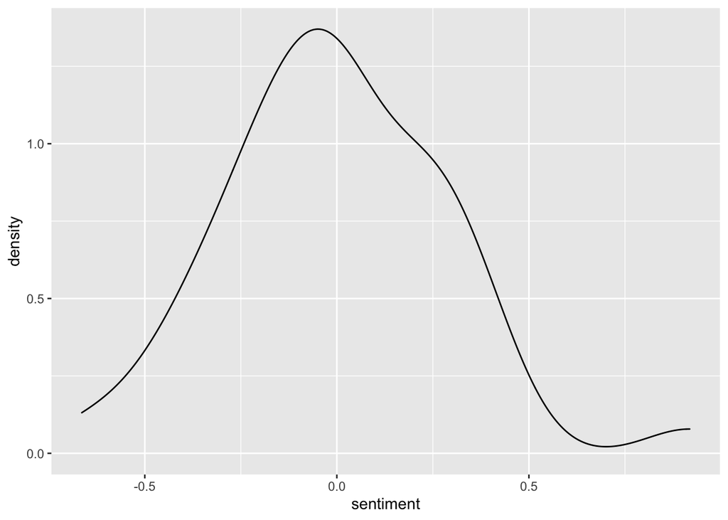

```r
  time_m_ch_8$chap8_sent_no <- as.numeric(time_m_ch_8$chap8_sent_no)

  time_m_ch_8 %<>% arrange(chap8_sent_no)

  time_m_ch_8_pick_section <- time_m_ch_8 %>%
    filter(90 < chap8_sent_no & chap8_sent_no < 130) %>%
    select(value)

  time_m_ch_8_pick_section_sent <- time_m_ch_8_pick_section %>%
    get_sentences() %>%
    sentiment()

  time_m_ch_8_pick_section_sent %>%
    ggplot() + geom_density(aes(sentiment))
```

With the sentiment analysis we did above, we glimpse the sentiment of chapter8, and found it nearly neutural, with a little trend to negative. We definately can do more to help see how the sentiment changes during the entire book.

## Conclusion

It is a story with a dystopian vision of humanity’s future. The time traveller used a time machine to travel to the future. He discovers that humans have evolved into two races: the childlike Eloys and the monstrous Morlocks. His machine disappeared, so he explored the future world. He rescued one female Eloi Weena who become his friend but eventually died in fire.After narrowly escaping the Morlocks, the time traveler retrieves his machine and travels further to the end of the world, before returning to his own time.

The Time Machine is interested in issues of social inequality and justice – in how to best organize our society so that we can live with each other without oppression. In Wells’s time, there was worry that the split between the “haves” and the “have-nots” was going to lead to violence. Today, well, maybe we’re not so worried about violence, but people still worry about the split between the rich and the poor. From the 1890s to our own time, people still work on the question that seems central to The Time Machine: What’s the best, most just way for society to be?

# Assignment part 2:

# Analysis of Numeric Data with Truenumbers

Using the above, make a statement about a set New England Counties. Consider what counties are wealthy or at risk, counties with large/small populations of higher education,etc. The statement you make should include ~10 true numbers. Complete the following steps: - Query the numberspace and tag numbers that fit your classification - Appropriately tag your observations, use the note to specify the feature your tag represents - Finally construct an kable table to display the numbers you tagged, their wrappers, values, and tags.

## Population with no health insurance

```r
## example1 no health insurance
nhi <- tnum.query("prop:population:no_health_insurance")

mapply(FUN = tnum.addTag,
guid = nhi$id,
tag = "county:population:no_health_insurance",
text = "the counties with large no health insurance population in New England")
```

```r
# double check our tag was added successfully #
tnum.getTagsOfTn(nhi[1,]$id)
```

```
## [1] "county:population:no_health_insurance"
```

```r
tag <- "no_health_insurance"

#kable
nhi <- nhi %>%
  unnest(si_value) %>%
  select(subject, mag, wrapper) %>%
  arrange(desc(mag)) %>%
  rename(no_insurance = mag) %>%
  rename(wrapper1 = wrapper) %>%
  mutate(Tag1 = tag) %>%
  filter(no_insurance > 16000)

nhi %>%
  kable(caption = "<b>Table Population with no health insurance</b>", digits = 4,
        format.args = list(big.mark = ",")) %>%   kable_minimal(full_width = F)
```

**Table Population with no health insurance**

| subject | no_insurance | wrapper1 | Tag1 |
| --- | --- | --- | --- |
| Connecticut:County:Fairfield | 78,804 | Connecticut:County:Fairfield has population:no_health_insurance = 78804 | no_health_insurance |
| Connecticut:County:New_Haven | 42,392 | Connecticut:County:New_Haven has population:no_health_insurance = 42392 | no_health_insurance |
| Massachusetts:County:Middlesex | 39,401 | Massachusetts:County:Middlesex has population:no_health_insurance = 39401 | no_health_insurance |
| Connecticut:County:Hartford | 35,782 | Connecticut:County:Hartford has population:no_health_insurance = 35782 | no_health_insurance |
| Rhode_Island:County:Providence | 33,911 | Rhode_Island:County:Providence has population:no_health_insurance = 33911 | no_health_insurance |
| Massachusetts:County:Suffolk | 30,114 | Massachusetts:County:Suffolk has population:no_health_insurance = 30114 | no_health_insurance |
| New_Hampshire:County:Hillsborough | 25,235 | New_Hampshire:County:Hillsborough has population:no_health_insurance = 25235 | no_health_insurance |
| Massachusetts:County:Essex | 23,578 | Massachusetts:County:Essex has population:no_health_insurance = 23578 | no_health_insurance |
| Massachusetts:County:Worcester | 20,324 | Massachusetts:County:Worcester has population:no_health_insurance = 20324 | no_health_insurance |
| Maine:County:Cumberland | 16,666 | Maine:County:Cumberland has population:no_health_insurance = 16666 | no_health_insurance |

We can see from the kable above, the counties with relative higher population of no insurance are: Connecticut:County:Fairfield, Connecticut:County:New_Haven, Massachusetts:County:Middlesex

## Female Population with no health insurance

```r
## example1 female population with no health insurance
nhif <- tnum.query("prop:population:no_health_insurance:female")

mapply(FUN = tnum.addTag,
guid = nhif$id,
tag = "county:population:female no_health_insurance",
text = "the counties with large no health insurance female population in New England")
```

```r
# double check our tag was added successfully #
tnum.getTagsOfTn(nhif[1,]$id)
```

```
## [1] "county:population:female no_health_insurance"
```

```r
tag <- "Female_no_health_insurance"

nhif <- nhif %>%
  unnest(si_value) %>%
  select(subject, mag,  wrapper) %>%
  arrange(desc(mag)) %>%
  rename(female_no_insurance = mag) %>%
  rename(wrapper2 = wrapper) %>%
  mutate(Tag2 = tag) %>%
  filter(female_no_insurance > 7000)

nhif %>%
  kable(caption = "<b>Table Female Population with no health insurance</b>", digits = 2,
        format.args = list(big.mark = ",")) %>%   kable_minimal(full_width = F)
```

**Table Female Population with no health insurance**

| subject | female_no_insurance | wrapper2 | Tag2 |
| --- | --- | --- | --- |
| Connecticut:County:Fairfield | 34,015 | Connecticut:County:Fairfield has population:no_health_insurance:female = 34015 | Female_no_health_insurance |
| Connecticut:County:New_Haven | 18,610 | Connecticut:County:New_Haven has population:no_health_insurance:female = 18610 | Female_no_health_insurance |
| Massachusetts:County:Middlesex | 16,265 | Massachusetts:County:Middlesex has population:no_health_insurance:female = 16265 | Female_no_health_insurance |
| Connecticut:County:Hartford | 14,910 | Connecticut:County:Hartford has population:no_health_insurance:female = 14910 | Female_no_health_insurance |
| Rhode_Island:County:Providence | 13,580 | Rhode_Island:County:Providence has population:no_health_insurance:female = 13580 | Female_no_health_insurance |
| Massachusetts:County:Suffolk | 11,562 | Massachusetts:County:Suffolk has population:no_health_insurance:female = 11562 | Female_no_health_insurance |
| New_Hampshire:County:Hillsborough | 10,615 | New_Hampshire:County:Hillsborough has population:no_health_insurance:female = 10615 | Female_no_health_insurance |
| Massachusetts:County:Essex | 9,342 | Massachusetts:County:Essex has population:no_health_insurance:female = 9342 | Female_no_health_insurance |
| Massachusetts:County:Worcester | 8,170 | Massachusetts:County:Worcester has population:no_health_insurance:female = 8170 | Female_no_health_insurance |
| Maine:County:Cumberland | 7,299 | Maine:County:Cumberland has population:no_health_insurance:female = 7299 | Female_no_health_insurance |

We can see from the kable above, the counties with relative higher female population of no insurance are: Connecticut:County:Fairfield, Connecticut:County:New_Haven, Massachusetts:County:Middlesex

## Female Proportion with no health insurance

```r
tag <- "Female_no_insurance_percentage"
nhi %>%
  full_join(nhif) %>%
  select(subject, no_insurance, female_no_insurance, wrapper1) %>%
  mutate(`female_no_insurance%` = female_no_insurance/no_insurance, .before= wrapper1) %>%
  arrange(desc(`female_no_insurance%`)) %>%
  mutate(Tag3 = tag) %>%
  filter(`female_no_insurance%` > 0.283) -> combine
combine %>%
  kable(caption = "<b>Female Proportion with no health insurance</b>", digits = 2,
        format.args = list(big.mark = ",")) %>%   kable_minimal(full_width = F)
```

**Female Proportion with no health insurance**

| subject | no_insurance | female_no_insurance | female_no_insurance% | wrapper1 | Tag3 |
| --- | --- | --- | --- | --- | --- |
| Connecticut:County:New_Haven | 42,392 | 18,610 | 0.44 | Connecticut:County:New_Haven has population:no_health_insurance = 42392 | Female_no_insurance_percentage |
| Maine:County:Cumberland | 16,666 | 7,299 | 0.44 | Maine:County:Cumberland has population:no_health_insurance = 16666 | Female_no_insurance_percentage |
| Connecticut:County:Fairfield | 78,804 | 34,015 | 0.43 | Connecticut:County:Fairfield has population:no_health_insurance = 78804 | Female_no_insurance_percentage |
| New_Hampshire:County:Hillsborough | 25,235 | 10,615 | 0.42 | New_Hampshire:County:Hillsborough has population:no_health_insurance = 25235 | Female_no_insurance_percentage |
| Connecticut:County:Hartford | 35,782 | 14,910 | 0.42 | Connecticut:County:Hartford has population:no_health_insurance = 35782 | Female_no_insurance_percentage |
| Massachusetts:County:Middlesex | 39,401 | 16,265 | 0.41 | Massachusetts:County:Middlesex has population:no_health_insurance = 39401 | Female_no_insurance_percentage |
| Massachusetts:County:Worcester | 20,324 | 8,170 | 0.40 | Massachusetts:County:Worcester has population:no_health_insurance = 20324 | Female_no_insurance_percentage |
| Rhode_Island:County:Providence | 33,911 | 13,580 | 0.40 | Rhode_Island:County:Providence has population:no_health_insurance = 33911 | Female_no_insurance_percentage |
| Massachusetts:County:Essex | 23,578 | 9,342 | 0.40 | Massachusetts:County:Essex has population:no_health_insurance = 23578 | Female_no_insurance_percentage |
| Massachusetts:County:Suffolk | 30,114 | 11,562 | 0.38 | Massachusetts:County:Suffolk has population:no_health_insurance = 30114 | Female_no_insurance_percentage |

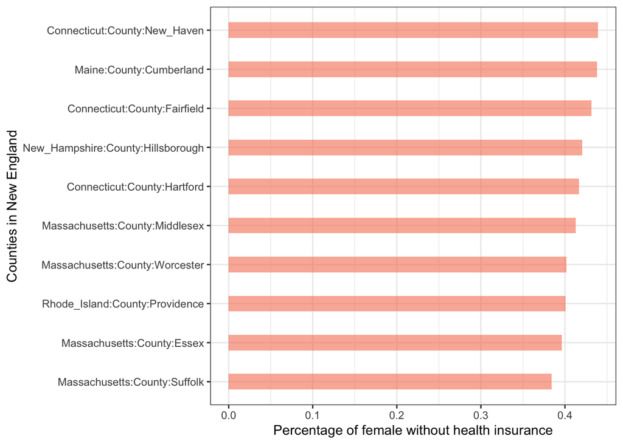

```r
library(ggplot2)
# load the library
library(forcats)

# Reorder following the value of another column:
combine %>%
  mutate(subject = fct_reorder(subject, `female_no_insurance%`)) %>%
  ggplot(aes(x=subject, y=`female_no_insurance%`)) +
    geom_bar(stat="identity", fill="#f68060", alpha=.6, width=.4) +
    coord_flip() +
    ylab("Percentage of female without health insurance") +
    xlab("Counties in New England") +
    theme_bw()
```